# Week 2A Assignment: Code Base – Movie Ratings

Author

Dillon Leeper

Published

September 10, 2026

## Approach

I plan to collect ratings for *Everything Everywhere All at Once* (2022), *The Batman* (2022), *Hereditary* (2018), *Obsession* (2025), *The Odyssey* (2026), and *Mean Girls* (2024) using Google Forms. I will store the responses in PostgreSQL and bring the data into R for a few simple summaries. I will send the form to friends so that at least five people respond.

For each movie, the form will have rating choices from 1 to 5 and a separate “Haven’t seen it” option. I will ask people to rate only movies they have seen. I will use a first name or alias to keep track of responses.

## Database structure

I will use three tables so that I do not have to repeat movie information for every person’s rating:

| Table | Planned columns |
| --- | --- |
| `users` | `user_id` (primary key), `name` (first name or alias) |
| `movies` | `movie_id` (primary key), `title`, `genre`, `duration` (minutes), `release_year` |
| `ratings` | `user_id`, `movie_id`, `rating` |

In `ratings`, the user and movie IDs will reference the other two tables. Together, they will identify one response per person per movie. Ratings will allow integers from 1 to 5 or SQL `NULL`. I will keep a row for each person/movie combination, including movies the person has not seen.

I will export the Google Forms responses and use them to populate the database. For the implementation, I will provide the SQL needed to create and populate the tables, even if I also use pgAdmin. I will keep database passwords out of my code and GitHub files.

## Missing ratings

I will store “Haven’t seen it” responses and unanswered ratings as SQL `NULL`, not zero. Once loaded into R, those values will be treated as `NA`. I will leave them out of average ratings and report the number of actual ratings and missing ratings for each movie. If a movie has no ratings, its average will stay missing. I will not replace missing ratings with made-up scores.

## Loading and summarizing in R

I plan to connect to PostgreSQL using the `DBI` and `RPostgres` packages. I will use `DBI::dbGetQuery()` with a SQL query that joins the three tables and returns an R dataframe. This should let me load the stored data without manually retyping it into R.

I will check that the ratings are in range and that each person/movie pair appears only once. Then I will summarize the average rating and number of ratings for each movie, along with missing counts. I may add a simple bar chart of average ratings. I will keep the small sample size in mind, especially if one movie has only a few ratings.

## Survey responses

The form collected 7 responses. Each respondent rated the movies they had seen from 1–5; “Haven’t seen it” and blank/unanswered cells are both treated as missing, never as 0.

| Timestamp | EEAAO | Batman | Hereditary | Obsession | Odyssey | Mean Girls | Alias |
| --- | --- | --- | --- | --- | --- | --- | --- |
| 9/10 15:28 | 4 | 3 | — | — | 5 | — | Eduardo |
| 9/10 15:44 | 4 | 3 | — | — | — | 5 | Annie |
| 9/10 15:45 | 2 | 2 | — | — | 4 | 3 | James |
| 9/10 15:47 | — | — | — | 5 | 4 | — | JOYEEEEEEEE |
| 9/10 15:49 | 5 | — | 3 | 5 | — | 5 | Chris |
| 9/10 15:51 | — | 4 | — | — | 4 | 3 | Garrett |
| 9/10 15:54 | 1 | — | — | — | 4 | 4 | Robyn |

I assigned `user_id` 1–7 in submission order (Eduardo, Annie, James, JOYEEEEEEEE, Chris, Garrett, Robyn) and `movie_id` 1–6 in the order the form asked them (Everything Everywhere All at Once, The Batman, Hereditary, Obsession, The Odyssey, Mean Girls). Reshaping the 7 respondents x 6 movies from this wide layout into the normalized `ratings` table means writing one row per person/movie pair — 42 rows total — with a `NULL` wherever a cell above shows “—”.

## Database setup

I refined the planned schema slightly once I had real data to work with:

- `users.user_id` and `movies.movie_id` are plain `INTEGER` primary keys rather than `SERIAL`. Both are assigned by hand from the form data, so there’s no reason to burn an auto-incrementing sequence on them.
- `ratings.rating_id` uses `GENERATED ALWAYS AS IDENTITY`, the modern equivalent of `SERIAL`, since those rows don’t have a natural key of their own.
- `movies.genre`, `duration`, and `release_year` are `NOT NULL` — I have verified values for all six movies, so there’s no reason to allow gaps there.
- `ratings.rating` stays nullable, with a `CHECK (rating BETWEEN 1 AND 5)` that only constrains non-null values, so a missing rating stays valid.
- `UNIQUE (user_id, movie_id)` on `ratings` enforces one row per person/movie pair at the database level, rather than trusting the load script to get it right.

```sql
CREATE TABLE users (
    user_id INTEGER PRIMARY KEY,
    name VARCHAR(50) NOT NULL
);

CREATE TABLE movies (
    movie_id INTEGER PRIMARY KEY,
    title VARCHAR(100) NOT NULL,
    genre VARCHAR(50) NOT NULL,
    duration INTEGER NOT NULL,
    release_year INTEGER NOT NULL
);

CREATE TABLE ratings (
    rating_id INTEGER GENERATED ALWAYS AS IDENTITY PRIMARY KEY,
    user_id INTEGER NOT NULL REFERENCES users(user_id),
    movie_id INTEGER NOT NULL REFERENCES movies(movie_id),
    rating INTEGER CHECK (rating BETWEEN 1 AND 5),
    UNIQUE (user_id, movie_id)
);
```

Genre, runtime, and release year for the `movies` table were verified against Wikipedia rather than guessed, since two of the six titles (*Obsession*, 2025, and *The Odyssey*, 2026) are recent enough that I didn’t want to rely on memory:

| movie_id | title | genre | duration (min) | release_year |
| --- | --- | --- | --- | --- |
| 1 | Everything Everywhere All at Once | Sci-Fi Comedy | 139 | 2022 |
| 2 | The Batman | Action/Crime | 176 | 2022 |
| 3 | Hereditary | Horror | 127 | 2018 |
| 4 | Obsession | Horror | 109 | 2025 |
| 5 | The Odyssey | Action/Fantasy | 172 | 2026 |
| 6 | Mean Girls | Musical Comedy | 112 | 2024 |

The full `CREATE TABLE` and `INSERT` statements for all three tables, including all 7 users and all 42 rating rows, are in `week02_2a_database.sql`, alongside this file. I ran that script against PostgreSQL directly (via `psql`) rather than through this document, per my original plan to keep database credentials out of my code and GitHub files.

## Load and validate in R

```r
library(DBI)
library(RPostgres)
library(dplyr)
library(ggplot2)
```

```r
con <- dbConnect(
  RPostgres::Postgres(),
  host     = Sys.getenv("PGHOST", "localhost"),
  port     = as.integer(Sys.getenv("PGPORT", "5432")),
  dbname   = Sys.getenv("PGDATABASE", "movie_ratings"),
  user     = Sys.getenv("PGUSER", "postgres"),
  password = Sys.getenv("PGPASSWORD")
)
```

```r
ratings_full <- dbGetQuery(con, "
  SELECT u.user_id, u.name, m.movie_id, m.title, m.genre, m.duration, m.release_year, r.rating
  FROM ratings r
  JOIN users u ON r.user_id = u.user_id
  JOIN movies m ON r.movie_id = m.movie_id
  ORDER BY u.user_id, m.movie_id
")
```

```r
# Both checks below are already enforced by the CHECK and UNIQUE constraints
# on the ratings table, so a successful load guarantees them -- this just
# re-confirms it from the R side.
range_violations <- sum(ratings_full$rating < 1 | ratings_full$rating > 5, na.rm = TRUE)

duplicate_pairs <- ratings_full |>
  count(user_id, movie_id) |>
  filter(n > 1) |>
  nrow()

c(range_violations = range_violations, duplicate_pairs = duplicate_pairs)
```

```
range_violations  duplicate_pairs
               0                0
```

```r
movie_summary <- ratings_full |>
  group_by(movie_id, title) |>
  summarize(
    avg_rating = round(mean(rating, na.rm = TRUE), 2),
    n_ratings  = sum(!is.na(rating)),
    n_missing  = sum(is.na(rating)),
    .groups = "drop"
  ) |>
  arrange(movie_id)

movie_summary
```

| movie_id | title | avg_rating | n_ratings | n_missing |
| --- | --- | --- | --- | --- |
| 1 | Everything Everywhere All at Once | 3.2 | 5 | 2 |
| 2 | The Batman | 3.0 | 4 | 3 |
| 3 | Hereditary | 3.0 | 1 | 6 |
| 4 | Obsession | 5.0 | 2 | 5 |
| 5 | The Odyssey | 4.2 | 5 | 2 |
| 6 | Mean Girls | 4.0 | 5 | 2 |

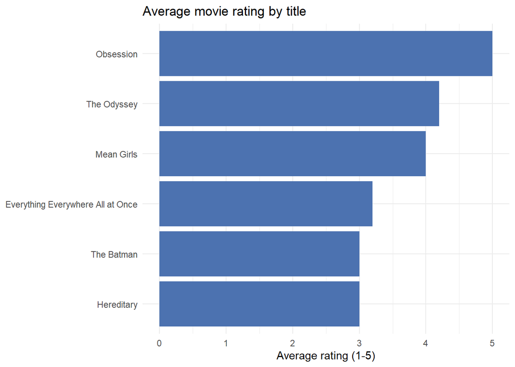

```r
ggplot(movie_summary, aes(x = reorder(title, avg_rating), y = avg_rating)) +
  geom_col(fill = "#4C72B0") +
  coord_flip() +
  labs(x = NULL, y = "Average rating (1-5)", title = "Average movie rating by title") +
  theme_minimal()
```

```r
dbDisconnect(con)
```

This document connects to my own local PostgreSQL instance using `PGHOST`/`PGPORT`/`PGDATABASE`/`PGUSER`/`PGPASSWORD` environment variables rather than hardcoded values, so no credentials appear in this file or on GitHub. `PGPASSWORD` is set in a project-level `.Renviron` file (excluded from version control via `.gitignore`) rather than typed into the code, so R picks it up automatically at startup. I loaded `week02_2a_database.sql` into PostgreSQL and confirmed the chunks above run cleanly against it end to end; the results below are the live output.

## Results

Both validation checks came back clean against the loaded data: 0 ratings outside the 1–5 range, and 0 duplicate person/movie pairs (as guaranteed by the schema’s `CHECK` and `UNIQUE` constraints).

| movie_id | title | avg_rating | n_ratings | n_missing |
| --- | --- | --- | --- | --- |
| 1 | Everything Everywhere All at Once | 3.20 | 5 | 2 |
| 2 | The Batman | 3.00 | 4 | 3 |
| 3 | Hereditary | 3.00 | 1 | 6 |
| 4 | Obsession | 5.00 | 2 | 5 |
| 5 | The Odyssey | 4.20 | 5 | 2 |
| 6 | Mean Girls | 4.00 | 5 | 2 |

## Conclusions

One data quality caveat is worth flagging before drawing any conclusions from the *Mean Girls* numbers specifically: the form listed *Mean Girls (2024)*, the movie-musical remake, and that’s what’s recorded in the `movies` table (`movie_id = 6`). I don’t think most respondents made that distinction when they answered, though – very few people have actually seen the 2024 version, while nearly everyone has seen the original 2004 *Mean Girls*. I suspect the ratings under `movie_id = 6` mostly reflect opinions of the 2004 film rather than the one actually in the database. I didn’t ask respondents which version they had in mind, so there’s no way to separate the two after the fact from this data alone; I’m noting it here as a known limitation rather than treating that average as reliable evidence about the 2024 film. A follow-up form would need to name the film more precisely (e.g. “Mean Girls (2024 musical remake)”) to avoid this ambiguity.

With only 7 respondents, these averages move a lot on a single rating – *Hereditary* and *Obsession* each have just 1–2 actual ratings, so their averages aren’t very informative yet, while *Everything Everywhere All at Once*, *The Odyssey*, and *Mean Girls* have 5 ratings each and are a bit more stable. *The Odyssey* and *Mean Girls* come out ahead of the two 2022 titles in this small sample, though I wouldn’t read much into the ranking given how few responses some movies have. The normalized three-table design did what it was meant to: I never had to repeat a movie’s genre, runtime, or year for each rating, and the `NULL` handling kept “haven’t seen it” responses from dragging down averages or getting mistaken for a real 0 rating.

## AI disclosure and citation

I used OpenAI’s ChatGPT to help organize my proposed approach and draft the initial planning section of this document from the assignment instructions and my choices.

I used Claude (Anthropic) to pull the 7 form responses from my Google Sheet, verify the genre/runtime/release-year facts for the `movies` table against Wikipedia, draft the `CREATE TABLE`/`INSERT` statements and the R/DBI loading and summary code, and run that SQL and the equivalent query logic against a live PostgreSQL instance to verify the results reported above.

AI citations:

OpenAI. (2026). *ChatGPT (GPT-5.6 Sol)* [Large language model]. Accessed September 10, 2026. https://chatgpt.com/.

Anthropic. (2026). *Claude (Sonnet 5)* [Large language model]. Accessed September 13, 2026. https://claude.ai/.